# RNA-seq analysis

# 1. Basic Unix

UNIX is an operatig system that was developed in the 1960 and it have been the base of widelly used operative sistems such as Linux and Mac OS. As the data coming out from biological outputs growing exponentially through time, Knowing the unix basics have become essential to do bioinformatics. Here there is a list of the most used commands:

| Commad | Use | Examples |
| --- | --- | --- |
| `cd` | Tove between directories | `cd FASTQ` (to enter a folder) |
| `cd ..` | To change to the parent of the current directory |  |
| `cd -` | To go to previous directory |  |
| `pwd` | Where am I? |  |
| `ls` | List files | `ls` (on this directory); `ls FASTQ` (list files inside FASTQ) |
| `mkdir` | make new directory | `mkdir my_folder` |
| `mv` | move a file or directory | `mv file my_folder/` (move file to a folder) |
| `cp` | copy file | `cp my_folder/* new_folder/` (copy all files of al folder) |
| `rm` | Remove a file or folder | `rm file`; `rm -rf folder` |
| `less` | Displays the contents of a file | `less file.txt` (press `q` to quit) |
| `head` | Displays the first ten lines of a file |  |
| `tail` | Displays the last ten lines of a file |  |
| `cat` | Print file content | `cat file1 file2 > file.total` (merge files) |
| `zcat` | Print file content of compresed files | `zcat SRR7889597.fastq.gz` |
| `gzcat` | mac OSx version of zcat | `gzcat SRR7889597.fastq.gz` |
| `wc` | word count | `wc -l file` (count lines inside of a file) |
| `grep` | Pattern matching | `grep patern file` (get lines that match the patern) |
| `cut` | extract columns from files | `cut -f 2 file` (extract second column) |
| `sort` | sort file by column | `sort -nr -k 2 file` (sort file by second column) |

**Exercise 1.0.1**

On the course directory, create a folder named `test_folder` and copy the smallest file inside `FASTQ/` folder. Then change the name of the folder that you just create to `to_delete` and finally remove this folder.

## 1.2 Efficient use of the termial

To accelerate our interaction with the terminal, we can use the TAB key:

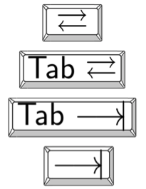

For instance, if you are at course folder and you write `ls Gene_` and then press TAB key once, it will complete the command to `ls Gene_annotation`. But if you just write `ls G` and press TAB two times, it will show you the two options (Gene_annotation and Genome).

An other powerful thing is to pipe (`|`) the output of one comand into and other command. For exmaple you can do:

`ls FASTQ/*.fastq.gz | wc -l`

To count all the FASTQ files that are stored at inside of `FASTQ/` folder.

Finally, if you want to now more, every command has its own options, you can see the entire description of a command using `man`. For instance, use man to know more about `head` typing on the command line:

`man head`

**Exercise 1.2.1**

Read the manual of `head` command. Then use it to extract the first 100 lines of `Gene_annotation/dm6.Ensembl.genes.gtf` and count all the lines that has `CDS` at the thrid column.

# 2. Input data format

In order to quantify mRNA by RNA-seq analysis, different files are required which as a different format. RNA-Seq reads are normally formatted as [FASTQ](https://en.wikipedia.org/wiki/FASTQ_format), SRA or CRAM. To process this data, the most common initial step is to map the reads to the genome, which is often formatted as [FASTA](https://en.wikipedia.org/wiki/FASTA_format). Finally, to quantify gene expression, we need to know which part of the genome encodes for genes. This information can be found at gene annotation files, which can be formatted as [GTF](http://mblab.wustl.edu/GTF22.html#fields) or [BED](https://genome.ucsc.edu/FAQ/FAQformat.html#format1) files. Explore the different hiperlinks provided for detailed information about the different file formats.

## 2.1 FASTA format

FASTA files contain nucleotide or amino acid sequence information. The data is composed of identifiers, which starts with `>` and nucleotide o amino acid sequences. Hundred of thousands of genomes coming from different species are available in public repositories as FASTA files. It is important to notice that a given species can have different genomic assemblies. For instance, a popular assembly human genome assembly is `hg19` that was published in February 2009, and as a huge amount of data is available for that assembly some researchers keep doing their analyses with that version. But other recent analyses have started to use `hg38` instead, which was published in December 2013 and represent a more curated version of the human genome.

For today’s practice, we are going to work with a smaller genome. We already have downloaded for you the `dm6` assembly of D. melanogaster’s genome, an invertebrate organism widely used as a model organism for genetic and behavioral studies. The genome file is at course material folder at `Genome/dm6.fa`.

**Exercise 2.1.1**

Count the number of sequences present at `dm6.fa` (hint: count lines that start with `>`, but as this is a special UNIX character, refer to it as `>’. Which command can be used for pattern matching and count lines?).

If each sequence is related to a chromosome, why do we find so many sequences? How many main scaffolds can you see?

**Exercise 2.1.2**

Can you calculate the exact number of nucleotides that this D. melanogaster assembly is made of? (hint: explore additional options of grep and wc)

## 2.2 FASTQ format

RNA-seq reads often come as FASTQ, which is an extension of FASTA file format. Every read is represented by four lines:

- First line: start with `@` and correspond to a read identifier.
- Second line: read nucleotide sequence.
- Third line: Start with `+` and it can be followed by additional information, but often it is just `+`.
- Fourth line: Phred quality score represent the reliability of a base call (as higher the better). It is encoded as ASCII characters. It can have different encodings, such as Sanger, Solexa, Illumina 1.3+ or Illumina 1.8+. Please check [FASTQ format description](https://en.wikipedia.org/wiki/FASTQ_format) for more details.

**Exercise 2.2.1**

Which of the fastq files found at `FASTQ/` has the highest and the lowest amout of reads? How many reads do they have? What is the read lenght?

## 2.3 Gene annotation

Efforts have been made to identify the genomic regions that encode for genes. This information can be stored as BED or GTF files (among other formats). BED files store information about genomic coordinates. Each row of a BED file represents a genomic interval, in the case of gene annotation file, it represents the start and end of a transcript. Exons coordinates are encoded as `blocks`, where the `blockStarts` column is a list of all exon starts relative to the transcript starts and `blockSizes` column contain all the exon sizes. Plase read [BED description format](https://genome.ucsc.edu/FAQ/FAQformat.html#format1) for more information.

GTF files instead are gene-centric annotations, in which a gene can be described by multiple rows. Each row contains the coordinates and additional information of a particular gene feature. Please check the full [GTF description](http://mblab.wustl.edu/GTF22.html)

**Exercise 2.3.1**

Get D. melanogaster gene annotation files for `dm6` assembly in from [UCSC Table Browser](http://genome-euro.ucsc.edu/cgi-bin/hgTables). Choosing the following values:

- clade: Insect.
- genome: D. melanogaster.
- assembly: Aug. 2014 (BDGP Release 6 + ISO1 MT/dm6).
- group: Gene and Gene Predictions.
- track: Ensembl Genes.
- table: ensGene.

And get the annotation files as BED and GTF (choosing the right output formats). Save the BED file as `dm6.Ensembl.genes.bed12` and GTF as `dm6.Ensembl.genes.gtf` at `Gene_annotation` folder.

**Exercise 2.3.2**

Process `dm6.Ensembl.genes.bed12` to find the five transcripts with the highest number of exons.

**Exercise 2.3.3**

Process `dm6.Ensembl.genes.bed12` to find the total number of genes

# 3. Quality control before alingment

## 3.1 FASTQC

To perform a QC of the Fastq files we can use *FastQC*. We can access to a basic manual of this tool by typing on `fastqc --help` on terminal.

Let’s create a directory to do a GC analysis of the data

**Exercise 3.1.1**

Create a directory named `QC`. Run `fastqc` for `FASTQ/SRR7889584.fastq.gz` store the resutls at the newly created folder. You will get an html file as output; Open it with a internet browser (Chrome, firefox, etc) and answere the following quesions

1. What is the read leght?
2. Does the quality score very throught the read lenght?
3. How is the data quality?

## 3.2 Metadata analysis on R-studio

The fastq.gz files that we have at `/FASTQ` correspond to RNA-seq data extracted from D. melanogaster brain samples. The data corresponding to a full study published last year on [Cell Reports](https://www.ncbi.nlm.nih.gov//pubmed/30355484) and the full study was published in [SRA archive](https://trace.ncbi.nlm.nih.gov/Traces/sra/?study=SRP162335).

**Exercise 3.2.1**

Check the [study runs](https://trace.ncbi.nlm.nih.gov/Traces/study/?acc=SRP162335) and compare with the file names from `FASTQ/` folder. Which tissues the samples were extracted from? Select the Runs that correspond to the files that we have and download the `RunInfo Table` corresponding to these tables and save it as `SraRunTable.txt` on the course folder.

**Exercise 3.2.2**

Open R-studio and open the `Analysis_Notebook.Rmd` file that is located at the course folder. This is an R-notebook file, that has all the code used to generate this document. But, now when you open this file you will be able to run `chunks` of code interactively inside R-studio. Run the following chunk by clicking at the green play button.

```r
library(data.table)

metadata <- fread("./SraRunTable.txt") #Please be sure to place the file under ./Course_Materials/00_Reproducible_RNA-SEQ_Initial_Processing/

metadata
```

By running this code, we imported the metadata as a data.table object, which correspond to a very convenient structure to manipulate data in R. For more information visit this [link](https://www.datacamp.com/community/tutorials/data-table-cheat-sheet). We can now easily manipulate the data! For example, we can filter the metadata rows, so we only see the ones corresponding to “central neurons”

```r
metadata[source_name=="central neurons" , ]
```

We can also get explore if we have a lowly sequenced sample filtering by the `MBases` values

```r
metadata[MBases < 100 , ]
```

Or get the average Mega bases across this sample

```r
metadata[  , mean(MBases) ]
```

To explore this visualy, we can plot with ggplot2. This is one of the most popular packages to visualize data. A basic code to visualize the Mbases distribution can be run as:

```r
library(ggplot2)

ggplot(data = metadata) +  # Frist layer - Data input
  geom_bar(aes(x=Run, y=MBases), stat = "identity")   # second layer - type of plot and axis
```

We can rotate the text to make it more visible

```r
ggplot(data=metadata) +
  geom_bar(aes(x=Run, y=MBases, ), stat = "identity") +
  theme(axis.text.x = element_text(angle = 45))  # Third layer -  visual configuration
```

inside `aes( )` are the variables and we can also define a variable as the colour:

```r
ggplot(data=metadata) +
  geom_bar(aes(x=Run, y=MBases, colour=source_name), stat = "identity") +
  theme(axis.text.x = element_text(angle = 45))
```

But for this particular type of graph, filling the bar with one colour is more suitable

```r
ggplot(data=metadata) +
  geom_bar(aes(x=Run, y=MBases, fill=source_name), stat = "identity") +
  theme(axis.text.x = element_text(angle = 45))
```

# 4. Mapping reads to the genome

After we have a diagnosis of the data quality, we can start to analyse the data. Usually the first step into the analysis requires mapping the RNA-seq reads to the genome. There are nomerous tools to do perform short read aligment and the choice of it shoud be carefolly made accordint ot the analysis goals and requirements. Hisat2 is a very fastq tool that have been shown to have a good performace on published benchmars.

To start mapping RNA-seq reads to the genome, we need to index the genome. The command to do this is `hisat2-build`.

## 4.1 Indexing the genome for Hisat2

```bash
hisat2-build --help
```

On the comand-line execute (you need to be at the Course_materials folder)

```bash
hisat2-build -p 5 Genome/dm6.fa Genome/Index/dm6
```

This command will use the genome (located at `Genome/dm6.fa`) and it will generate the index files on `Genome/Index/`. All the files will start with `dm6` prefix

## 4.2 Runing hisat2

To map the reads to the genome we need to run hisat2. Take a quick look to hisat2’s description

```bash
hisat2 --help
```

**Exercise 4.2.1**

Run hista2 for the smallest file, SRR7889582.fastq, located at FASTQ folder using 5 proccesors. Save the results inside a folder named `hisat2` (create it with mkdir), under the file name of hisat2/SRR7889582.sam hint: Use -p -U -x -S flags

# 5. Quality control after alingment

# 6. Gene quantification

## 7.1 Bigwig files

## 7.2 Bigwig files

# 8. Workflow mannager

—————————-Day two——————————————-